# Assessment of benthic impact

Author

Daniel van Denderen & Jan-Geert Hiddink

## Introduction

This step shows how to estimate benthic state and impact relative to the benthic carrying capacity. The scale ranges from 1 (no impact) to 0 (complete loss of the original community). The estimate is derived from the logistic growth equation, where benthic depletion from bottom trawling depends on the type of gear used, and recovery after trawling (i.e., the intrinsic growth rate) is determined by the biomass–longevity distribution.

## Install and Load Required Libraries

We first load again the libraries and custom functions.

```r
# Load necessary libraries and custom functions
source("Libraries_needed.R")
source("Functions.R")
```

## Load benthic sensitivity and fishing intensity

We can use the benthic sensitivity layer and a fishing intensity layer to predict impact. Fishing intensity is estimated using the swept area, and is defined as the ratio between the area of the site trawled each year and the site’s total area (SAR, swept area ratio).

```r
# Load grid data from step 1
load("model/Region_grid_sensitivity.RData")

# rm all rows without a sensitivity prediction
grid_sf <- subset(grid_sf,!is.na(grid_sf$intercept))
grid_sf <- subset(grid_sf,!is.na(grid_sf$intercept))

# load example fishing data
FiD <- read.csv("data/Bottom_fishing/Fishing_simple.csv")
head(FiD)
```

```
        csquares TBB_SurfSAR OT_SurfSAR TD_SurfSAR Seine_SurfSAR
1 7500:371:247:3          NA  0.2896039  0.1480683            NA
2 7500:371:246:4          NA  0.5917787  1.4384541     0.3128804
3 7500:371:246:3          NA  0.1109737  1.3321237            NA
4 7500:371:245:4          NA  0.2030615  1.4711499     0.6231534
5 7500:371:245:3          NA  0.1317628  1.6211001     0.3207024
6 7500:371:144:4          NA  0.1512764  1.0397071     0.3128804
```

## Estimate benthic depletion from fishing

We can estimate the depletion rate that the trawls cause on the benthic community by multiplying SAR with the depletion rate per trawl pass estimated from experimental trawling studies.

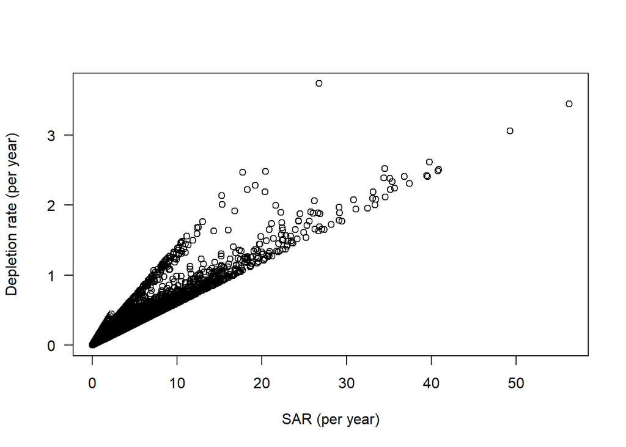

```r
# combine the sensitivity grid with the fishing data
grid_sf <- cbind(grid_sf, FiD[match(grid_sf$csquares,
                                    FiD$csquares),
                              c(2:5)]) #TBB, OT, TD, Seine

# now calculate the depletion rate per grid cell;
# value for TBB, OT and TD is from Hiddink et al. PNAS 2017 Table S4
# value for Seine is put similar to otter trawling
Depl_TBB  <- 0.14 * grid_sf$TBB_SurfSAR
Depl_OT   <- 0.06 * grid_sf$OT_SurfSAR
Depl_TD   <- 0.20 * grid_sf$TD_SurfSAR
Depl_sein <- 0.06 * grid_sf$Seine_SurfSAR

# get total depletion
Depl <- cbind(Depl_TBB,Depl_OT,Depl_TD,Depl_sein)
grid_sf$Depl_tot <- rowSums(Depl,na.rm=T)

# get total SAR
grid_sf$SAR <- rowSums(
  st_drop_geometry(grid_sf)[,c("TBB_SurfSAR","OT_SurfSAR",
                               "TD_SurfSAR","Seine_SurfSAR")],na.rm=T)

# make a plot between SAR and depletion
plot(grid_sf$Depl_tot~grid_sf$SAR,
     xlab="SAR (per year)",ylab="Depletion rate (per year)",las=1)
```

## Benthic state and impact

The impact of trawling on benthic biota depends on two key parameters: the depletion rate (*d*) and the intrinsic growth rate (*r*, hereafter referred to as the recovery rate). Both have been estimated through empirical meta-analyses.

The Relative Benthic State (RBS) can be estimated using the RBS function, which requires four inputs:

- Depletion rate of the grid cell (Fd)
- Slope of the biomass-longevity curve (a)
- Intercept of the biomass-longevity curve (b)
- Longevity-to-recovery scaling parameter (H), used to calculate recovery rate as *r = H / longevity*

RBS represents the proportion of total community biomass remaining under fishing pressure. The corresponding fishing impact is expressed as *1 – RBS*.

```r
# one grid
one_grid <- grid_sf[1,]
state <- RBS(
    Fd = one_grid$Depl_tot,
    a  = one_grid$slope,
    b  = one_grid$intercept,
    H  = 5.31)

state
```

```
[1] 0.9966664
```

```r
impact <- 1 - state

impact
```

```
[1] 0.003333594
```

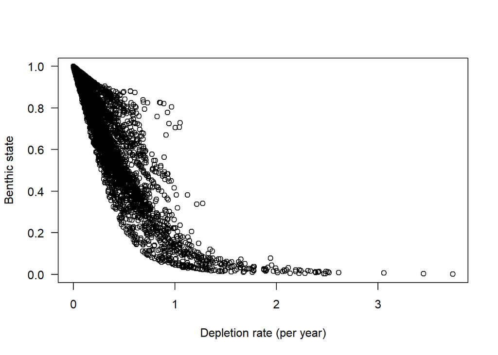

```r
# all grids
state <- c()
  for(j in 1:nrow(grid_sf)){
   state[j] <- RBS(
    Fd = grid_sf$Depl_tot[j],
    a  = grid_sf$slope[j],
    b  = grid_sf$intercept[j],
    H  = 5.31)
  }

grid_sf$state <- state
grid_sf$impact <- 1 - state

# plot state as a function of total depletion
  plot(grid_sf$state~grid_sf$Depl_tot,
       ylab="Benthic state",xlab="Depletion rate (per year)",las=1)
```

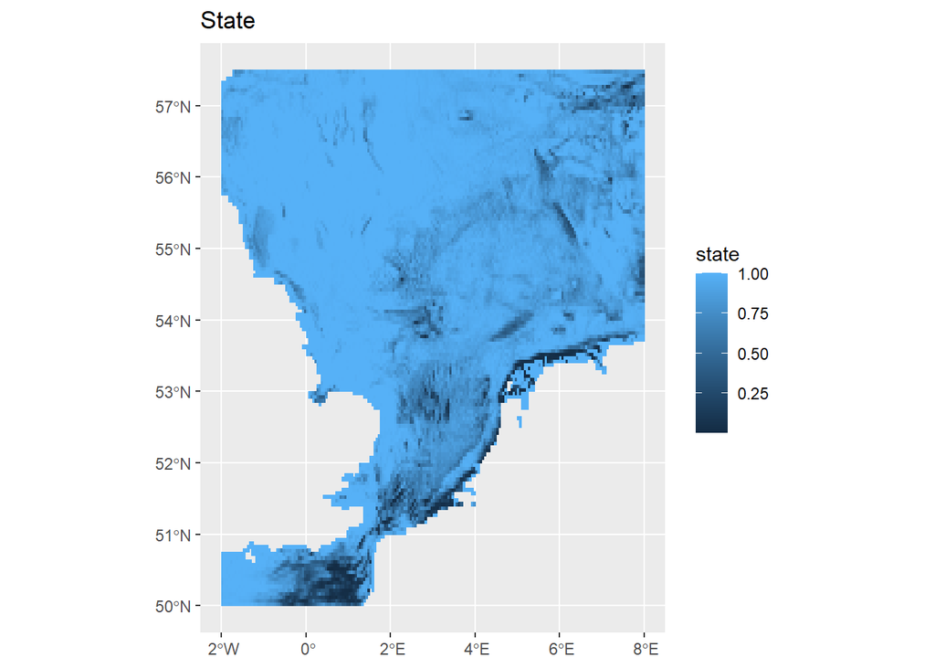

```r
# make a map
ggplot() +
  geom_sf(data = grid_sf, aes(col = state,fill= state)) +
  ggtitle("State")
```

## State by habitat type

Now that we have a prediction for each grid cell, we can estimate how the average state varies by habitat type.

```r
# mean RBS by MSFD habitat type
aggregate(state~Dominant_MSFD,data=grid_sf, FUN=mean)
```

```
                                   Dominant_MSFD     state
1                  Circalittoral coarse sediment 0.8747202
2                   Circalittoral mixed sediment 0.9129395
3                              Circalittoral mud 0.8102262
4           Circalittoral rock and biogenic reef 0.9811648
5                             Circalittoral sand 0.8280136
6                  Infralittoral coarse sediment 0.8571207
7                   Infralittoral mixed sediment 1.0000000
8                              Infralittoral mud 0.9997176
9           Infralittoral rock and biogenic reef 1.0000000
10                            Infralittoral sand 0.8403687
11                                            Na 0.8414156
12        Offshore circalittoral coarse sediment 0.8146566
13         Offshore circalittoral mixed sediment 0.8913118
14                    Offshore circalittoral mud 0.8950573
15 Offshore circalittoral rock and biogenic reef 0.9901131
16                   Offshore circalittoral sand 0.9164593
17                        Upper bathyal sediment 0.8386092
```

```r
# fraction of area above a RBS of 0.7
grid_sf$state_area <- ifelse(grid_sf$state >0.7,1,0)
sum(grid_sf$state_area*grid_sf$area_sqkm)/sum(grid_sf$area_sqkm)
```

```
[1] 0.8814107
```

## Save the grid with impact prediction

Finally, we save the grid with the impact prediction.

```r
# Save grid with sensitivity prediction

save(grid_sf, file="model/Region_grid_impact.RData")
```

## Done?

The risk assessment framework can be used to explore different scenarios of management interventions.

*Task*: In pairs, discuss and implement a management intervention scenario and estimate its effect on the benthic state.

Examples of interventions:

- Gear removal: reduce or eliminate the fishing intensity of one (or multiple) gear types.
- Area-based management: close a specific area to bottom fishing.

Prepare a short presentation summarizing your scenario and the outcomes.